# Predicting Democratic Primary Polling using Twitter Sentiment Analysis

## The Problem

As the 2020 Democratic Primary Election approaches, both pundits and campaign teams use polling data to assess their relative position in the race and strategize on how to improve it. Candidates can leverage datasets that contain demographic information on voters to determine what those voters are looking for in a candidate in order to adjust their platform to draw the largest voter base. These datasets are often purchased from other organizations or collected through surveys. However, many voter opinions can be found on a platform that is free and where sentiments are expressed freely: Twitter. The purpose of this analysis is to see what sense can be made of the massive set of Tweets that mention Democratic Primary candidates using a Natural Language Processing (NLP) technique called sentiment analysis. By extracting information on how voters feel about different candidates from their activity on Twitter, the goal is to gain additional insights on voter sentiment, and more broadly to evaluate Twitter as a reliable source of information on voters. Ultimately, we want to decide if campaigns should use Twitter sentiment analysis data to measure the strength of their platform and to find room for improvement.

## The Data

### Polling data

The polling data, the target variable in this analysis, comes from Nate Silver’s website [FiveThirtyEight](https://data.fivethirtyeight.com/). This dataset contains polling data on all the Democratic Primary Candidates from a variety of pollsters. The variable I will try to predict will be an average of data from all the pollsters in this dataset.

The graphic below shows polling percentages over time for all candidates.

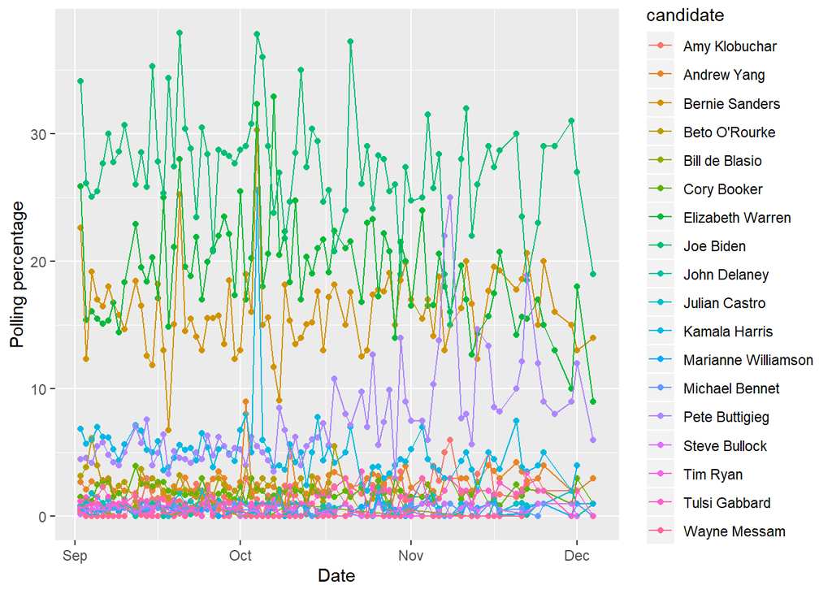

### Tweet data

The Tweet dataset, which I use to generate the independent variables, or features, was collected using the Twitter API. Unfortunately, Twitter’s API limits the number of past Tweets that can be queried, so these Tweets were instead collected using the Streaming endpoint of the API. This endpoint allows the client to open up a “stream” with certain filtering parameters that returns Tweets that fit the filter as they are posted in real time. The filtering parameters that I used were the names of the top 18 Democratic Primary candidates (as of September 13, 2019). I used a Python script to collect data from the Streaming endpoint, which I hosted on my Raspberry Pi and had it run biweekly using a cron scheduler. cron is a Linux command line tool that allows a program to execute at set intervals. It is important to note that Twitter rate limits their API, meaning that not every Tweet that is posted comes through the endpoint. This rate is reportedly about 1% of all Tweets being produced at a given time ([source](https://stackoverflow.com/questions/34962677/twitter-streaming-api-limits)). As such, the data collected using this method is not necessarily indicative of what all Twitter users are saying at a given point in time. Here is a look at the dataset after it has been collected and put into a dataframe using Python, then loaded into R.

Data from Twitter Streaming API

| candidate | text | username | followers | date | location |
| --- | --- | --- | --- | --- | --- |
| Bernie Sanders | Whenever I watch the democratic debates I wait for Bernie Sanders old ass to drop | babycailie | 149 | Fri Sep 13 01:55:33 +0000 2019 | work |
| Bernie Sanders | Bernie Sanders looks tired DemDebate | 7810o | 346 | Fri Sep 13 01:55:33 +0000 2019 | southern california, usa |
| Joe Biden | In all seriousness is Joe Biden ok | Nate_Denny | 1260 | Fri Sep 13 01:55:33 +0000 2019 | plano, tx |
| Andrew Yang | Andrew Yang just said Puerto Rico is a countryDemocraticDebate | TheMahdiMonster | 893 | Fri Sep 13 01:55:34 +0000 2019 | NA |
| Joe Biden | Age isnxe2x80x99t Joe Bidenxe2x80x98s problem Itxe2x80x99s his vote to authorize the War of 1812nnDemDebate | AnandWrites | 515767 | Fri Sep 13 01:55:34 +0000 2019 | brooklyn, new york |

Who gets tweeted about the most?

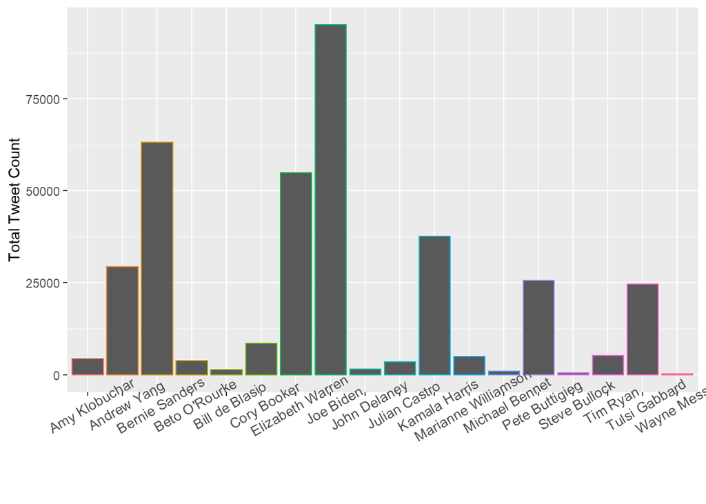

How has the frequency of Tweets changed over time for each of the candidates?

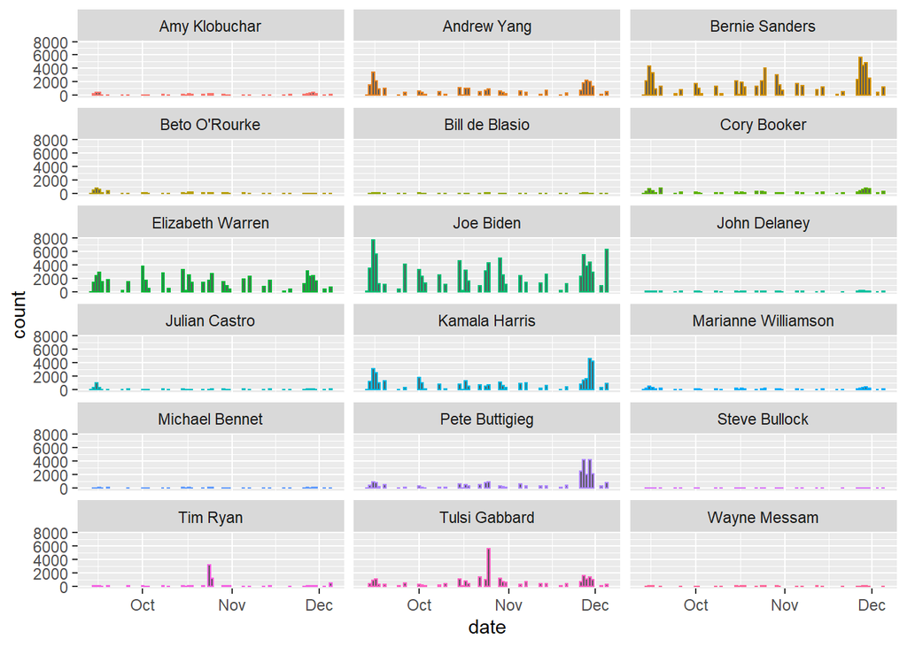

For most candidates, the number of Tweets that mention them stays somewhat constant over time. One notable exception is Andrew Yang, who had a lot of people tweeting about him in September but has dropped off since. This could be related to Yang’s announcement during the Third Democratic Debate on September 12 that he would randomly select 10 American families to be given $1000 per month for a year as a universal basic income pilot program ([source](https://www.politico.com/story/2019/09/12/andrew-yang-120000-giveaway-for-ubi-pilot-program-1493622)).

Who tweets about each candidate?

Top Tweeters by Candidate

| Candidate | Account Name | Number of Tweets |
| --- | --- | --- |
| Amy Klobuchar | riotwomennn | 29 |
| Andrew Yang | Simon23105395 | 97 |
| Bernie Sanders | reallycoolbot | 928 |
| Beto O’Rourke | FunnyBeto | 32 |
| Beto O’Rourke | NessiePeyote | 32 |
| Bill de Blasio | thenetlines | 28 |
| Cory Booker | thehill | 35 |
| Elizabeth Warren | BASHAM03628084 | 156 |
| Joe Biden | motivationbot_ | 803 |
| John Delaney | Kennedemon | 48 |
| Julian Castro | DonaldWray9 | 25 |
| Kamala Harris | somsirsa | 101 |
| Marianne Williamson | mariannebot1 | 265 |
| Michael Bennet | TheRealLilXza | 12 |
| Pete Buttigieg | ShamefulRight | 102 |
| Steve Bullock | AndrewBond3 | 21 |
| Tim Ryan | caleyah5 | 41 |
| Tulsi Gabbard | CultofTulsi | 102 |
| Wayne Messam | hugetinymistake | 6 |

@thehill is the only verified account on this list. Many of the others have been deleted or are clearly bots due to their Tweet content and posting rate.

How many people are seeing tweets about each candidate?

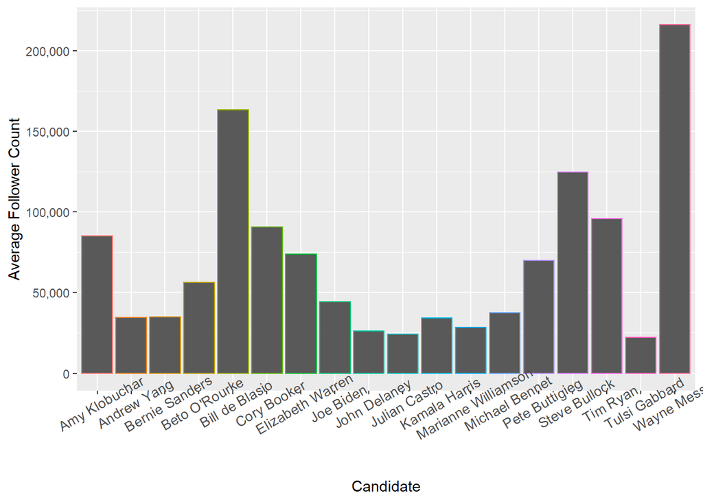

This graphic is interesting but possibly misleading. Wayne Messam dominates this plot, but this could be due to the fact that not many accounts mention him besides large news outlets. As such, average follower count may not be the best way to measure how many people are exposed to content about a given candidate.

Who is the most Tweeted-about candidate in each state?

[interactive chart not shown]

This graphic was created by parsing the “location” field of the Tweet dataset to extract state names and abbreviations. Biden dominates this graphic; unsurprising, as he is the most Tweeted about candidate overall. Sanders and Warren are both the most Tweeted about candidate in their home states of Vermont and Massachusetts, respectively, but also carry some other states. Tulsi Gabbard only makes the graphic as she is the most Tweeted about candidate in her home state of Hawaii.

### Sentiment Analysis

In order to gain additional insights into the Twitter data, NLP techniques are used to turn the qualitative data from the “content” field of the Tweets into quantitative data that can be analyzed. Three different techniques were used to perform sentiment analysis on the Tweet data. Two of these were implemented during data pre-processing in Python. The first used a Python library called [TextBlob](https://textblob.readthedocs.io/en/dev/). TextBlob provides a pre-compiled model that automatically tokenizes text and outputs two float values: a polarity score between -1 and 1 where 1 is very positive and -1 is very negative, and a subjectivity score between 0 and 1 where 1 is very subjective and 0 is very objective. The advantage of TextBlob is that it is very easy to use; the downside is that it provides limited ability to optimize the model. For the second sentiment analysis technique, I used the Python package keras to create a deep learning model using a Convolution Neural Network (CNN) with the help of [this tutorial](https://realpython.com/python-keras-text-classification/). Each sentence was first turned into a vector representing the count of each word in the sentence in a process known as vectorization, converting the text data to an integer array. The CNN consisted of two layers and was trained on three labeled datasets of reviews from Yelp, Amazon, and IMDb. After some minor optimization, the model was run on the corpus of content from collected Tweets to predict their sentiment. For the CNN sentiment data, 1 indicates a positive sentiment while 0 indicates a negative sentiment. The final sentiment analysis technique was conducted in R using the tidytext package following the method that was covered in lecture. Each Tweet was broken down into words, each of which was given a sentiment score between -5 (negative) and 5 (positive) using the [AFINN Sentiment Lexicon](http://corpustext.com/reference/sentiment_afinn.html). The word scores were summed to generate a score for each Tweet. I averaged sentiment analysis data and the other independent features by candidate and by day in order to more closely align with the dependent variable in the polling dataset. Additionally, note that the sentiment analysis data has been scaled for many of the below graphics; this is done to make it easier to visually compare the sentiment data with polling data over time.

Here, a comparison of sentiment techniques for a few selected candidates is performed. TextBlob and CNN values (between -1 and 1) have been scaled by 100; tidytext values (between -5 and 5) have been scaled by 20. The purpose of these graphics is to get a visual understanding of any correlation that might exist between the different techniques. Some dates to keep in mind: the three debates that happened during this period on September 12th, October 15th, and November 20th.

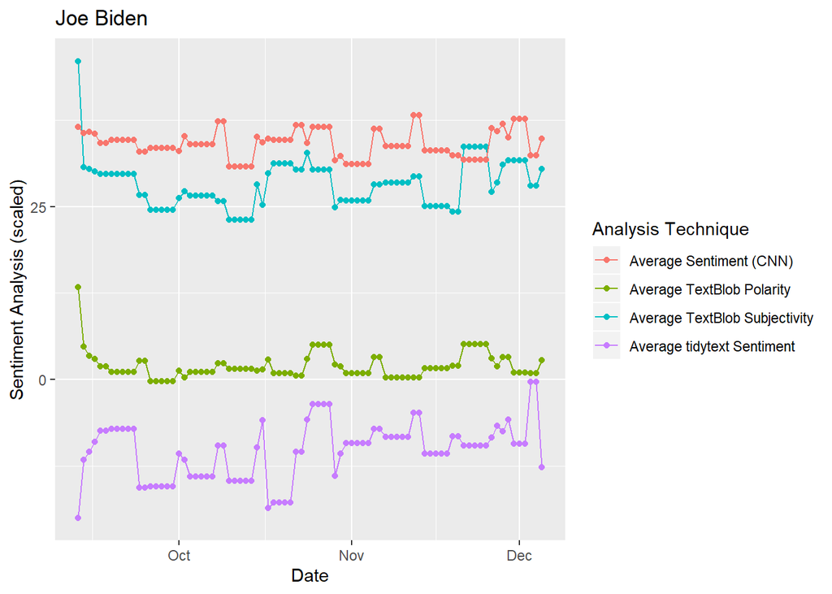

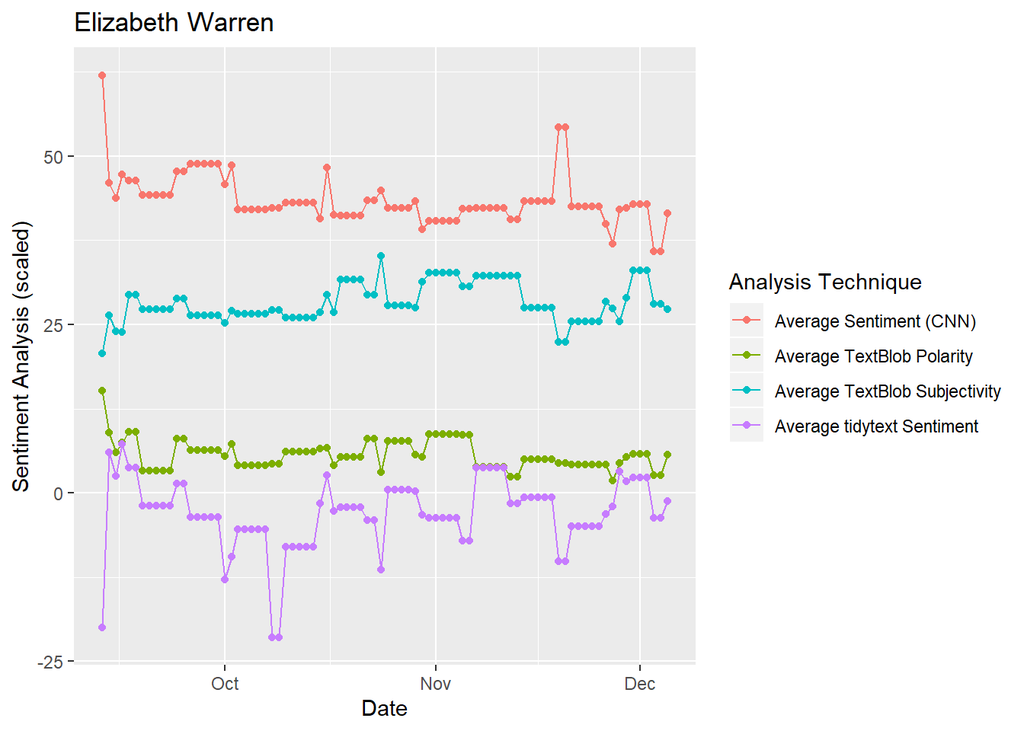

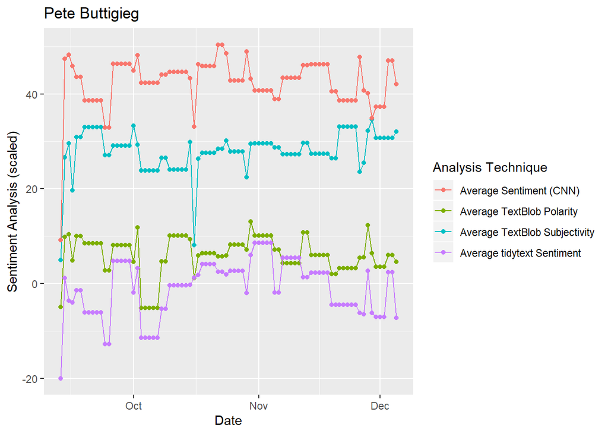

It can be seen from these examples that the techniques do not track sentiment in the same way, but there are distinct parts of each plot where similarities are apparent.

Sentiment comparison across all candidates.

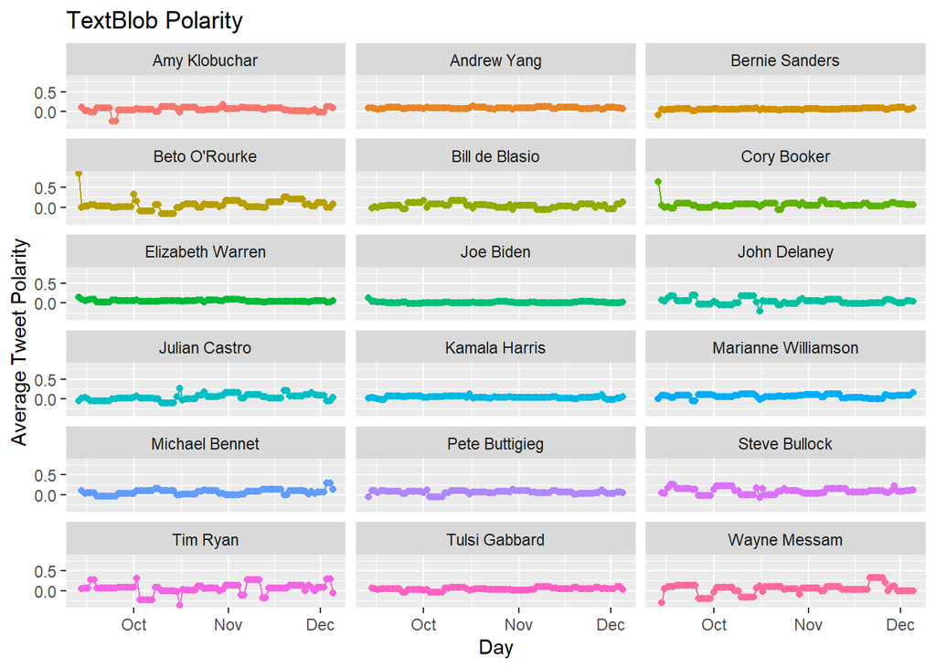

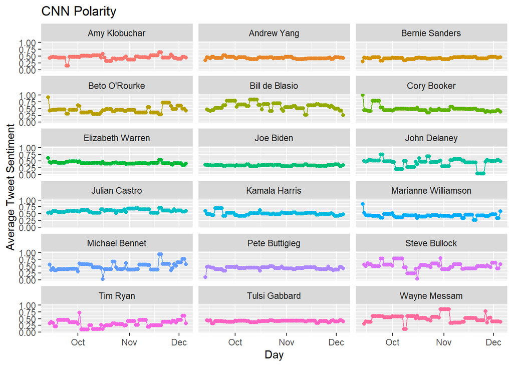

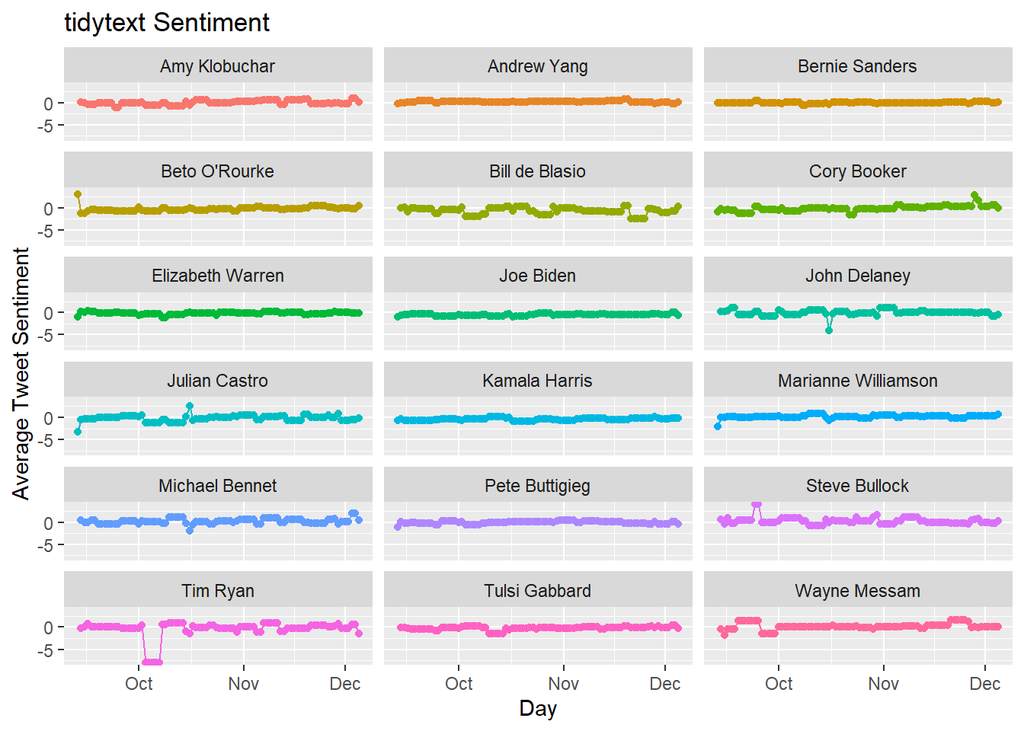

How is Tweet sentiment distributed geographically for the most Tweeted-about candidate, Joe Biden?

[interactive chart not shown]

Sentiments here are from the CNN method, and darker blue in the graphic corresponds to more positive sentiment. This graphic did not completely align with my expectations; I would have expected more positive sentiment in traditional Democratic strongholds like California and New York, but instead the most positive sentiment towards Biden is found in North Dakota. This graphic may be misleading because not as many people are Tweeting from states like North Dakota in comparison to California, so a few Tweets might dominate the sentiment analysis average in those states with less Tweets.

### Predicting How Candidates Poll

As a first step in predicting polling percentages, we can inspect sentiment analysis and polling side-by-side for a few candidates to get an understanding of whether this might be a good predictor. Again, the sentiment analysis data is scaled and the purpose of these graphics is to attempt to visualize possible correlations between these techniques and the target variable, polling percentage.

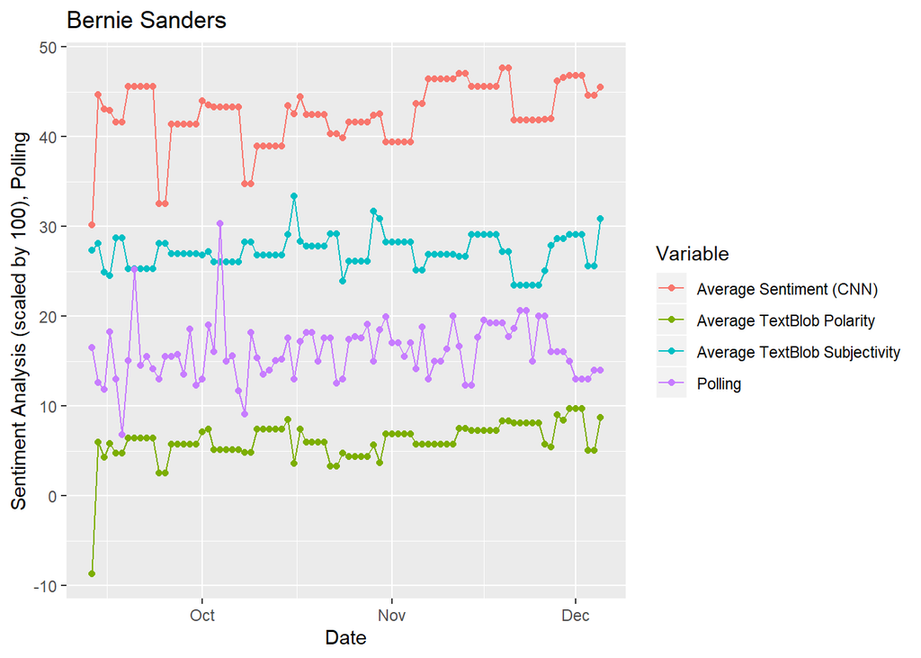

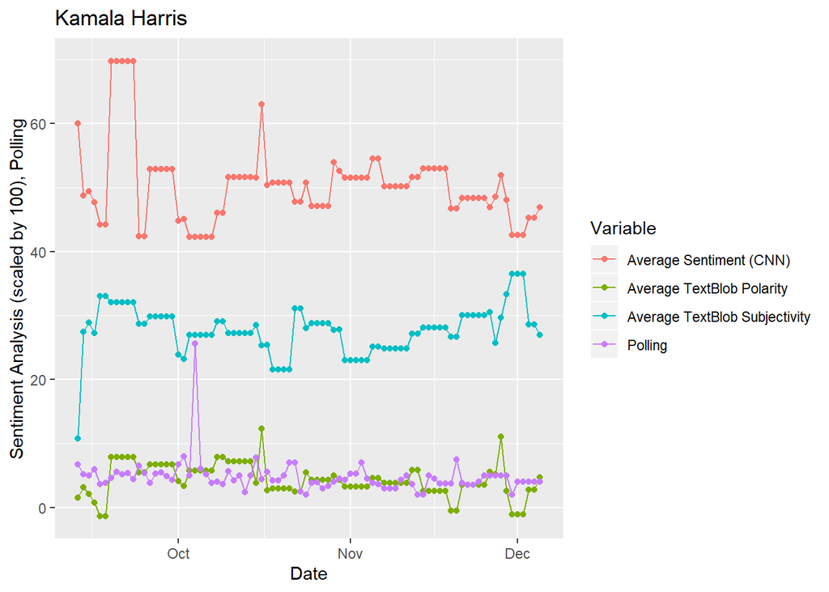

#### Conditional Means

One possible way of predicting polling data is using conditional means. In this technique, the target variable is averaged at different quantiles of an input feature as a means of prediction. The first predictor I use is the average follower count for Tweets about each candidate by day. The polling percentage for each candidate averaged at quartiles of the average follower count is used as the predictor.

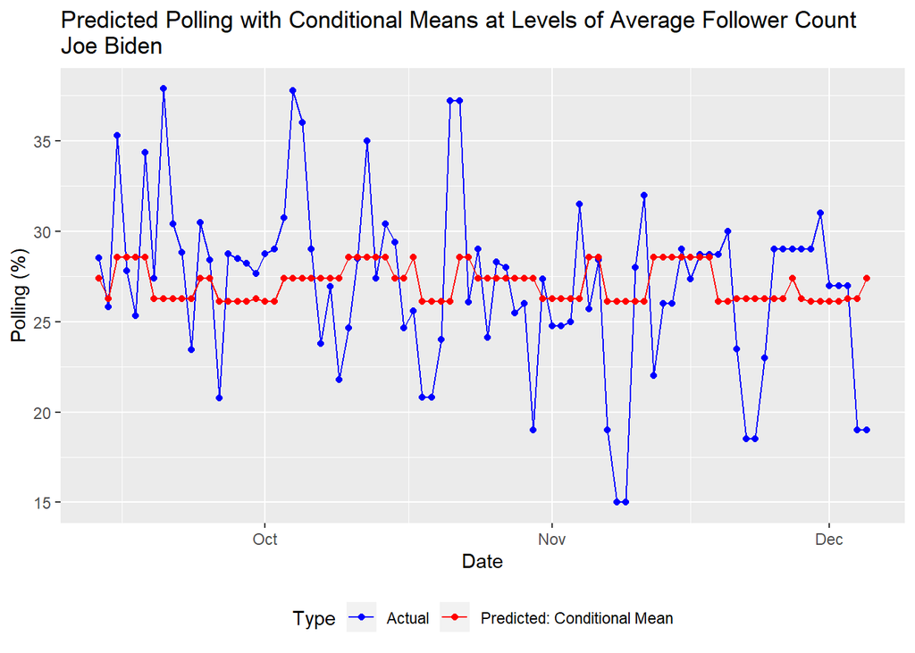

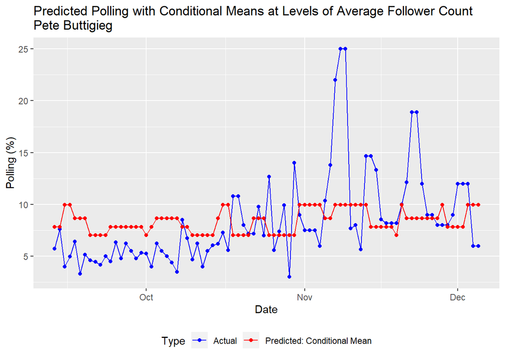

For both Biden and Buttigieg, the conditional mean on follower count tracks the basic trends in polling, but fails to capture large swings in the polls.

For my second predictor, I take the average polling percentage at quartiles of a few different sentiment analysis techniques.

Grouping by CNN Polarity

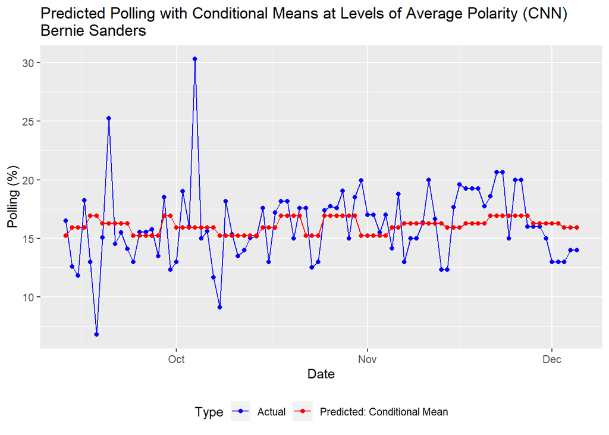

Grouping by TextBlob Subjectivity and Polarity

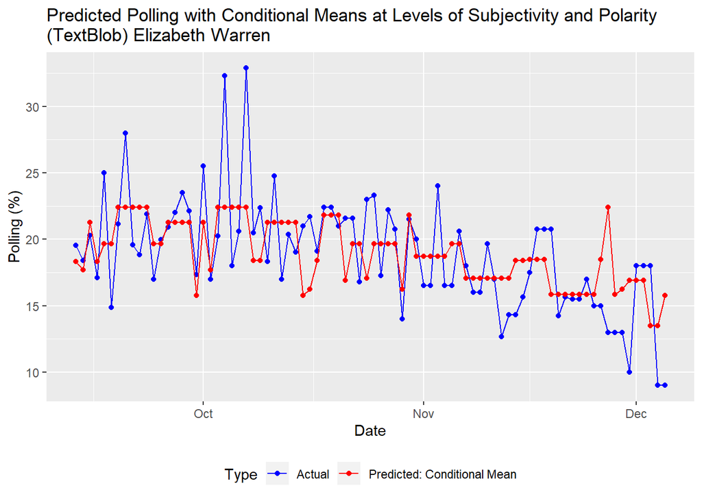

The CNN Sentiment does not appear to track Sanders’ polling very well. The TextBlob sentiment analysis, on the other hand, appears to track Elizabeth Warren’s polling relatively closely, but again fails to track large changes.

#### Regression

The first step is to visualize the distribution of the target variable and the features to see if they need to be transformed.

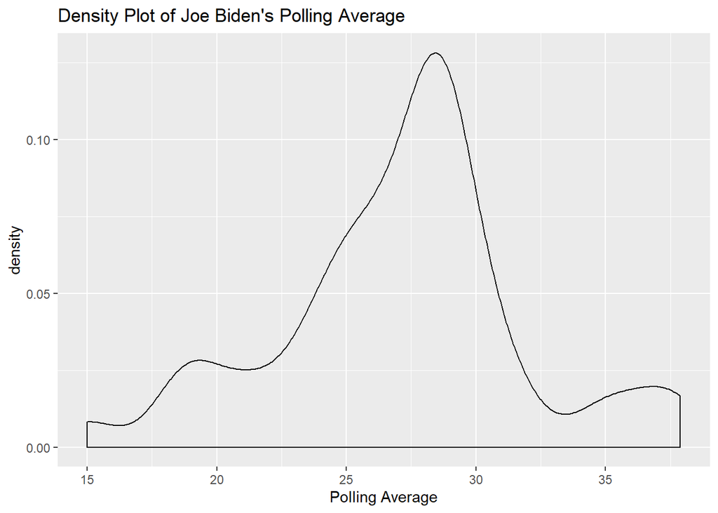

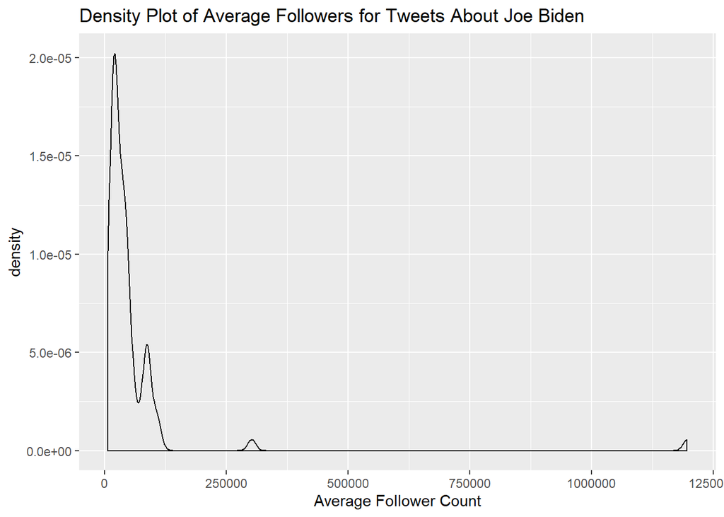

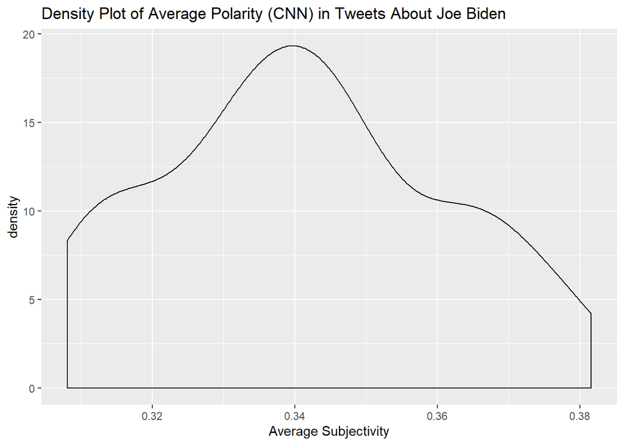

From these plots, I determined that the target variable is approximately normally distributed while the features, with the exception of CNN polarity, have exponential distributions. As such, I log transform those features that are exponentially distributed.

I use both a simple linear model and a linear stepwise regression to attempt to model polling data. The simple linear model is essentially a conditional mean at every level of the input features, creating a continuous function that predicts the target variable. The linear stepwise regression is the same principle, except the computer is allowed to choose the combination of input features that yields the lowest error.

**Biden: Coefficients of Simple Linear Regression Model**

|  | *Dependent variable:* |
| --- | --- |
|  | polling_avg |
| log(followers_avg + 1) | 0.675 |
|  | (0.750) |
| log(subjectivity_avg + 1) | -32.029 |
|  | (31.000) |
| log(polarity_avg + 1) | -0.635 |
|  | (44.860) |
| cnn_sentiment_avg | 36.974 |
|  | (30.372) |
| Constant | 15.443 |
|  | (12.133) |
| Observations | 84 |
| R<sup>2</sup> | 0.046 |
| Adjusted R<sup>2</sup> | -0.003 |
| Residual Std. Error | 4.756 (df = 79) |
| F Statistic | 0.945 (df = 4; 79) |
| *Note:* | p<0.1; p<0.05; p<0.01 |

**Biden: Coefficients of Final Model from Stepwise Linear Regression**

|  | *Dependent variable:* |
| --- | --- |
|  | polling_avg |
| date | -0.058*** |
|  | (0.021) |
| Constant | 1,085.541*** |
|  | (373.344) |
| Observations | 84 |
| Log Likelihood | -246.639 |
| Akaike Inf. Crit. | 497.278 |
| *Note:* | p<0.1; p<0.05; p<0.01 |

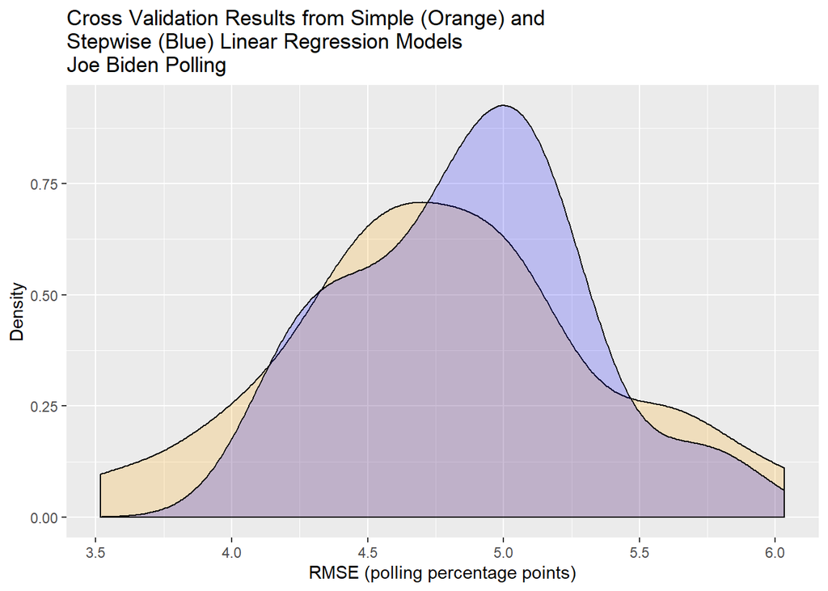

Finally, I create a model using the full dataset with all the candidates using the same technique as for the Biden predictive model. In these models, the candidate name is included as a factor covariate.

**All candidates - Coefficients of Simple Linear Regression Model**

|  | *Dependent variable:* |
| --- | --- |
|  | polling_avg |
| log(followers_avg + 1) | 0.021 |
|  | (0.036) |
| log(subjectivity_avg + 1) | -0.278 |
|  | (0.916) |
| log(polarity_avg + 1) | -0.371 |
|  | (0.930) |
| cnn_sentiment_avg | 0.297 |
|  | (0.657) |
| candidateAndrew Yang | 0.745** |
|  | (0.339) |
| candidateBernie Sanders | 14.036*** |
|  | (0.339) |
| candidateBeto O’Rourke | -0.726** |
|  | (0.339) |
| candidateBill de Blasio | -1.712*** |
|  | (0.352) |
| candidateCory Booker | -0.171 |
|  | (0.339) |
| candidateElizabeth Warren | 16.849*** |
|  | (0.341) |
| candidateJoe Biden | 25.042*** |
|  | (0.346) |
| candidateJohn Delaney | -1.663*** |
|  | (0.341) |
| candidateJulian Castro | -1.190*** |
|  | (0.355) |
| candidateKamala Harris | 2.731*** |
|  | (0.340) |
| candidateMarianne Williamson | -1.490*** |
|  | (0.340) |
| candidateMichael Bennet | -1.472*** |
|  | (0.338) |
| candidatePete Buttigieg | 6.303*** |
|  | (0.341) |
| candidateSteve Bullock | -1.577*** |
|  | (0.341) |
| candidateTim Ryan | -1.697*** |
|  | (0.354) |
| candidateTulsi Gabbard | -0.533 |
|  | (0.339) |
| candidateWayne Messam | -1.938*** |
|  | (0.348) |
| Constant | 1.800*** |
|  | (0.535) |
| Observations | 1,504 |
| R<sup>2</sup> | 0.925 |
| Adjusted R<sup>2</sup> | 0.924 |
| Residual Std. Error | 2.175 (df = 1482) |
| F Statistic | 869.537*** (df = 21; 1482) |
| *Note:* | p<0.1; p<0.05; p<0.01 |

**All candidates - Coefficients of Final Model from Stepwise Linear Regression**

|  | *Dependent variable:* |
| --- | --- |
|  | polling_avg |
| date | -0.005** |
|  | (0.002) |
| `candidateAndrew Yang` | 0.806*** |
|  | (0.290) |
| `candidateBernie Sanders` | 14.114*** |
|  | (0.290) |
| `candidateBeto O'Rourke` | -0.669** |
|  | (0.290) |
| `candidateBill de Blasio` | -1.596*** |
|  | (0.291) |
| `candidateElizabeth Warren` | 16.943*** |
|  | (0.290) |
| `candidateJoe Biden` | 25.109*** |
|  | (0.290) |
| `candidateJohn Delaney` | -1.608*** |
|  | (0.291) |
| `candidateJulian Castro` | -1.093*** |
|  | (0.290) |
| `candidateKamala Harris` | 2.832*** |
|  | (0.290) |
| `candidateMarianne Williamson` | -1.438*** |
|  | (0.290) |
| `candidateMichael Bennet` | -1.388*** |
|  | (0.291) |
| `candidatePete Buttigieg` | 6.394*** |
|  | (0.290) |
| `candidateSteve Bullock` | -1.497*** |
|  | (0.291) |
| `candidateTim Ryan` | -1.687*** |
|  | (0.291) |
| `candidateTulsi Gabbard` | -0.469 |
|  | (0.291) |
| `candidateWayne Messam` | -1.852*** |
|  | (0.291) |
| Constant | 85.544** |
|  | (42.214) |
| Observations | 1,504 |
| Log Likelihood | -3,291.462 |
| Akaike Inf. Crit. | 6,618.923 |
| *Note:* | p<0.1; p<0.05; p<0.01 |

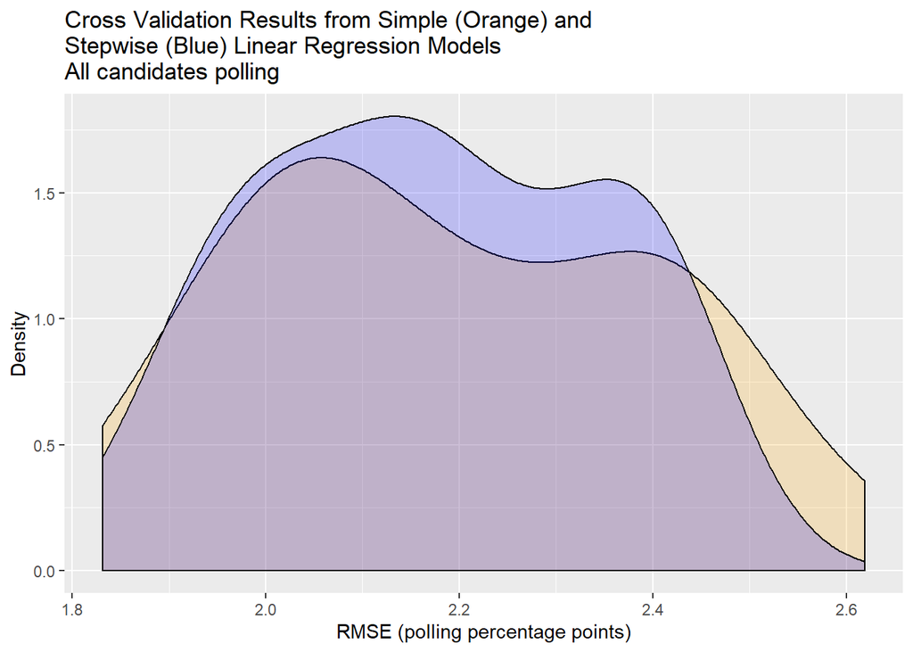

From these RMSE distributions it can be seen that both of these models outperform the model created just for Joe Biden in terms of predicting polling percentages. There is not much difference between the simple linear regression and the stepwise regression for this data.